# Datos para prácticas de Jose-Ramon-Martinez-Batlle

José-Ramón Martínez-Batlle** (jmartinez19@uasd.edu.do) Facultad de Ciencias, Universidad Autónoma de Santo Domingo (UASD) Santo Domingo, República Dominicana

## 0.1 Carga de paquetes y lectura de datos

```r
library(vegan)
library(sf)
library(tidyverse)
library(tmap)
library(kableExtra)
library(foreach)
library(leaps)
library(caret)
r <- 'R/'
gh_content <- 'https://raw.githubusercontent.com/'
gh_zonal_stats <- paste0(gh_content,
                         'geofis/zonal-statistics/0b2e95aaee87bf326cf132d28f4bd15220bb4ec7/out/')
repo_analisis <- 'biogeografia-master/scripts-de-analisis-BCI/master'
repo_sem202202 <- 'biogeografia-202202/material-de-apoyo/master/practicas/'
devtools::source_url(paste0(gh_content, repo_analisis, '/biodata/funciones.R'))
devtools::source_url(paste0(gh_content, repo_sem202202, 'train.R'))
devtools::source_url(paste0(gh_content, repo_sem202202, 'funciones.R'))
fuentes_practica <- 'fuentes/practica-04/'
source(paste0(r, 'funciones.R'))
```

Cargar la matriz de comunidad.

```r
mc <- read.csv(paste0(fuentes_practica, 'matriz-comunidad-', params$estudiante, '.csv'))[,-1]
# nrow(mc) #Número de filas, equivale a número de sitios muestreados con registros de presencia
# ncol(mc)  #Número de columnas, equivale a número de especies, riqueza
data.frame(Especies = names(mc)) %>%
  kable(booktabs=T) %>%
  kable_styling(latex_options = c("HOLD_position", "scale_down")) %>%
  gsub(' NA ', '', .) #Lista de especies
```

| Especies |
| --- |
| sp01 |
| sp02 |
| sp03 |
| sp04 |
| sp05 |
| sp06 |
| sp07 |
| sp08 |
| sp09 |
| sp10 |
| sp11 |
| sp12 |

```r
# table(word(names(mc), 1, 1)) #Número de especies por género
data.frame(`Número de sitios donde fue reportada la especie` = sort(colSums(mc), decreasing = T), check.names = F) %>%
  kable(booktabs=T) %>%
  kable_styling(latex_options = c("HOLD_position", "scale_down")) %>%
  gsub(' NA ', '', .) # Número de hexágonos en los que está presente cada especie
```

|  | Número de sitios donde fue reportada la especie |
| --- | --- |
| sp11 | 12 |
| sp03 | 10 |
| sp02 | 9 |
| sp04 | 9 |
| sp06 | 9 |
| sp07 | 9 |
| sp12 | 9 |
| sp01 | 8 |
| sp05 | 8 |
| sp08 | 8 |
| sp09 | 8 |
| sp10 | 6 |

Transformar la matriz de comunidad. Este paso es importante, lo explico [aquí](https://www.youtube.com/watch?v=yQ10lp0-nHc&list=PLDcT2n8UzsCRDqjqSeqHI1wsiNOqpYmsJ&index=10)

```r
mc_t <- decostand(mc, 'hellinger') #Hellinger, funciona con datos de presencia/ausencia
# Otras transformaciones posibles con datos de presencia/ausencia
# mc_t <- decostand(mc, 'normalize') #Chord
# mc_t <- decostand(log1p(mc), 'normalize') #Chord
# mc_t <- decostand(mc, 'chi.square') #Chi-square
```

Cargar la matriz ambiental.

```r
#Matriz ambiental
env <- read_csv(paste0(fuentes_practica, 'matriz-ambiental-', params$estudiante, '.csv'))[, -1]
all(rownames(mc) == rownames(env)) #Si es TRUE, se sigue adelante
```

```
## [1] TRUE
```

## 0.2 Análisis de agrupamiento

A continuación, el **análisis de agrupamiento** propiamente. La parte más importante es generar un árbol, a partir de una matriz de distancias, que haga sentido desde el punto de vista de la comunidad y la distribución de las especies. Primero cargaré paquetes específicos de esta técnica y generaré la matriz de distancias.

```r
library(broom)
library(cluster)
library(gclus)
library(pvclust)
mc_d <- vegdist(mc_t, "euc")
```

A continuación, generaré árboles usando distintos métodos. Explico detalladamente estas técnicas en el [repo](https://github.com/biogeografia-master/scripts-de-analisis-BCI), y en los vídeos (13 a 16) de la lista mencionada arriba [“Ecología Numérica con R” de mi canal](https://www.youtube.com/playlist?list=PLDcT2n8UzsCRDqjqSeqHI1wsiNOqpYmsJ).

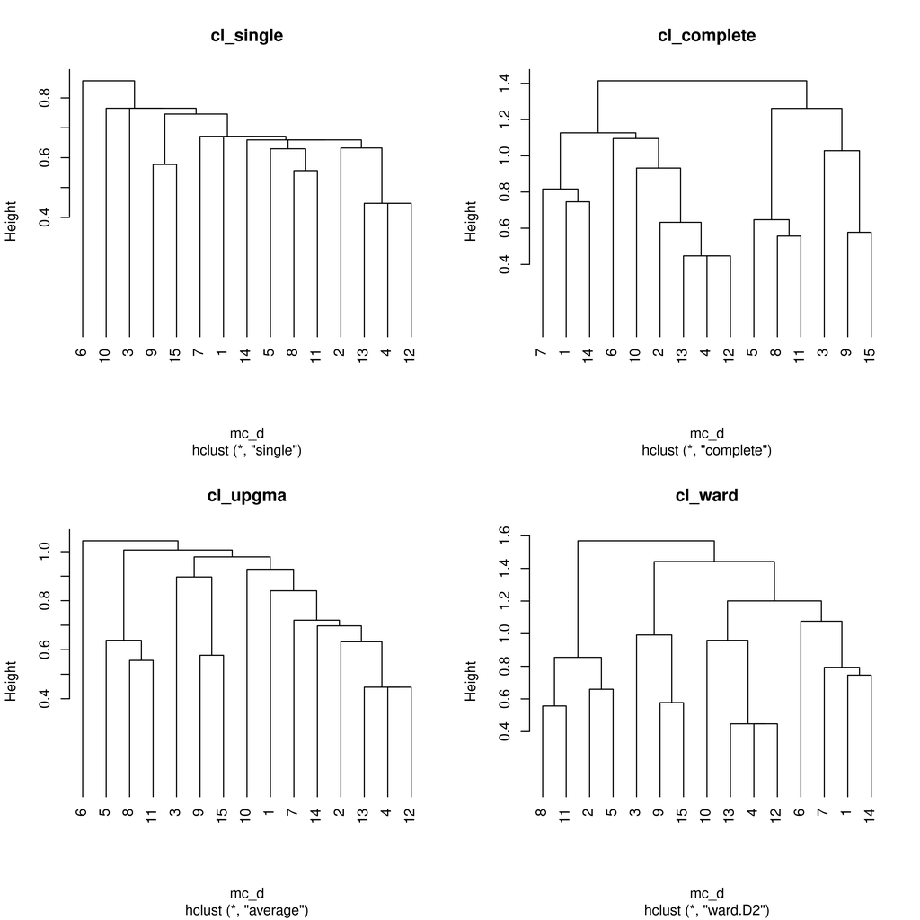

```r
lista_cl <- list(
        cl_single = hclust(mc_d, method = 'single'),
        cl_complete = hclust(mc_d, method = 'complete'),
        cl_upgma = hclust(mc_d, method = 'average'),
        cl_ward = hclust(mc_d, method = 'ward.D2')
)
par(mfrow = c(2,2))
invisible(map(names(lista_cl), function(x) plot(lista_cl[[x]], main = x, hang = -1)))
```

```r
par(mfrow = c(1,1))
```

A continuación, **calcularé la distancia y la correlación cofenéticas; esta última, la correlación cofenética,se utiliza como criterio flexible para elegir el método de agrupamiento idóneo, pero no debe usarse de manera estricta**. Se supone que el método con la mayor correlación cofenética explica mejor el agrupamiento de la comunidad. Si quieres comprender mejor esta técnica, consulta el vídeo que te referí en el párrafo anterior, así como los libros de referencia. Normalmente, el método UPGMA obtiene la mayor correlación cofenética, pero esto se debe a que su procedimiento de obtención maximiza precisamente dicha métrica. No es recomendable conservar un único método de agrupamiento, normalmente es bueno usar al menos dos. Ward es muchas veces recomendado como método de contraste, por basarse en procedimientos de cálculo muy distintos a los de UPGMA.

```r
map_df(lista_cl, function(x) {
        coph_d <- cophenetic(x)
        corr <- cor(mc_d, coph_d)
        return(corr)
})
```

```
## # A tibble: 1 × 4
##   cl_single cl_complete cl_upgma cl_ward
##       <dbl>       <dbl>    <dbl>   <dbl>
## 1     0.619       0.631    0.737   0.548
```

Ahora, calcularé **las anchuras de silueta, una métrica que ayuda a determinar en cuántos grupos se organiza la comunidad; las anchuras de silueta no deben usarse como método estricto, y sólo debe usarse de forma flexible para informarnos sobre el número máximo de grupos posibles**. Considera las siguientes reglas:

- El número ideal es 3 grupos, de 4 a 5 grupos es aceptable, 6 o más grupos se considera difícil de interpretar, o es un resultado poco útil; 1 grupo es un resultado sin sentido.
- Si obtienes distintos grupos, **pero uno o varios están compuestos por un único sitio, observa qué ocurre en ese sitio**, pues es probable que contenga especie raras sólo presentes en él. En este caso, es recomendable explorar dos alternativas para evitar el grupo formado por un único sitio: ver qué ocurre usando distintos métodos o elegir cortar el árbol en un número de grupos menor.

### 0.2.1 Anchuras de siluetas para método UPGMA

```r
# UPGMA
anch_sil_upgma <- calcular_anchuras_siluetas(
        mc_orig = mc,
        distancias = mc_d,
        cluster = lista_cl$cl_upgma)
anch_sil_upgma
```

```
## $anchuras_siluetas
##  [1] 0.00000000 0.12309983 0.15803381 0.19976868 0.18940221 0.18618049
##  [7] 0.16966499 0.14879605 0.14290278 0.10270537 0.10581719 0.07566421
## [13] 0.05857864 0.00000000 0.00000000
##
## $n_grupos_optimo
## [1] 4
```

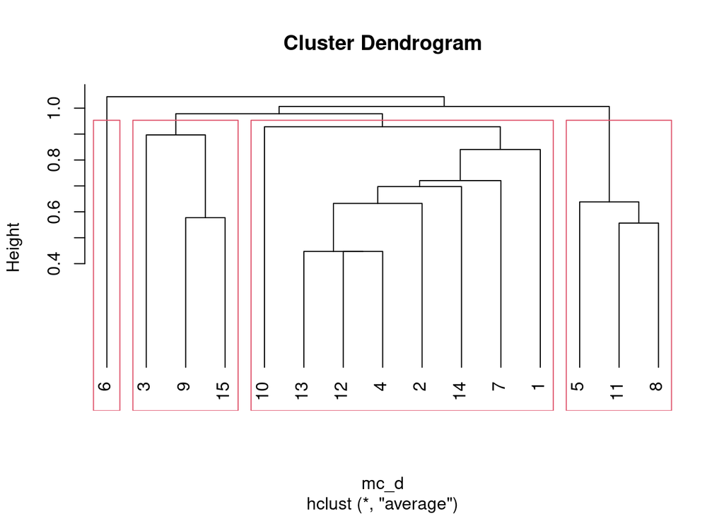

```r
u_dend_reord <- reorder.hclust(lista_cl$cl_upgma, mc_d)
plot(u_dend_reord, hang = -1)
rect.hclust(
        tree = u_dend_reord,
        k = anch_sil_upgma$n_grupos_optimo)
```

```r
resultado_evaluacion_upgma <- evaluar_arbol(u_dend_reord, anch_sil_upgma$n_grupos_optimo)
```

Tras cortar el árbol, la evaluación practicada recomendó lo siguiente: **“Árbol no recomendado para usarse por producir grupos compuestos por 2 elementos o menos”**

### 0.2.2 Anchuras de siluetas para método Ward

```r
# Ward
anch_sil_ward <- calcular_anchuras_siluetas(
        mc_orig = mc,
        distancias = mc_d,
        cluster = lista_cl$cl_ward)
anch_sil_ward
```

```
## $anchuras_siluetas
##  [1] 0.00000000 0.13074053 0.15921812 0.16122283 0.16504020 0.16950493
##  [7] 0.15945837 0.13424547 0.13550604 0.12578651 0.10581719 0.07566421
## [13] 0.05857864 0.00000000 0.00000000
##
## $n_grupos_optimo
## [1] 6
```

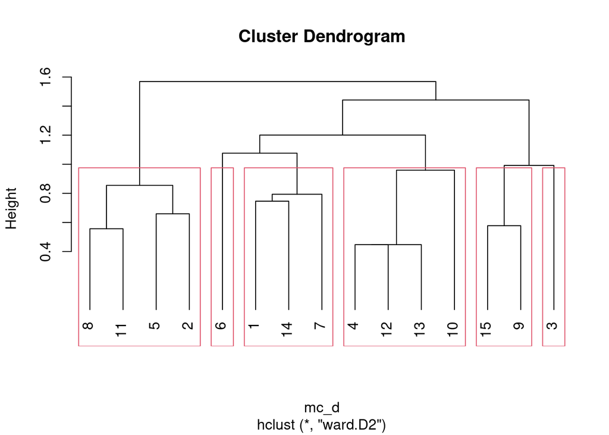

```r
w_dend_reord <- reorder.hclust(lista_cl$cl_ward, mc_d)
plot(w_dend_reord, hang = -1)
rect.hclust(
        tree = w_dend_reord,
        k = anch_sil_ward$n_grupos_optimo)
```

```r
resultado_evaluacion_ward <- evaluar_arbol(w_dend_reord, anch_sil_ward$n_grupos_optimo)
```

### 0.2.3 Remuestreo por *bootstrap* multiescalar

Una forma alterna de evaluar árboles consiste en usar el remuestreo por *bootstrap* multiescalar. No me interesa que profundices en ella, sólo presentártela como técnica probabilística para evaluar árboles generados por métodos determinísticos. La técnica es documentada en Borcard, Gillet, and Legendre (2018), de la cual puedes un resumen en [este cuaderno](https://github.com/biogeografia-master/scripts-de-analisis-BCI/blob/master/aa_analisis_de_agrupamiento_2_intepretacion_resultados.md#evaluaci%C3%B3n-mediante-remuestreo-por-bootstrap-multiescalar) y en [este vídeo (minuto 51:33)](https://youtu.be/y1ZZh9ajT_U?list=PLDcT2n8UzsCRDqjqSeqHI1wsiNOqpYmsJ&t=3093). El remuestreo por *bootstrap* multiescalar valida la robustez de los análisis de agrupamiento tomando múltiples muestras aleatorias de los datos en diferentes tamaños. Este proceso determina qué grupos son consistentemente identificados como clústeres, generando valores de probabilidad aproximadamente insesgados (AU) que son considerados más fiables que las probabilidades de *bootstrap* tradicionales (BP). Esta técnica ayuda a identificar y confirmar patrones robustos en los datos.

Lo aplicaré primero al árbol generado por el método UPGMA.

```r
# UPGMA
if(interactive()) dev.new()
cl_pvclust_upgma <-
        pvclust(t(mc_t),
                method.hclust = "average",
                method.dist = "euc",
                iseed = 99, # Resultado reproducible
                parallel = TRUE)
```

```
## Creating a temporary cluster...done:
## socket cluster with 7 nodes on host 'localhost'
## Multiscale bootstrap... Done.
```

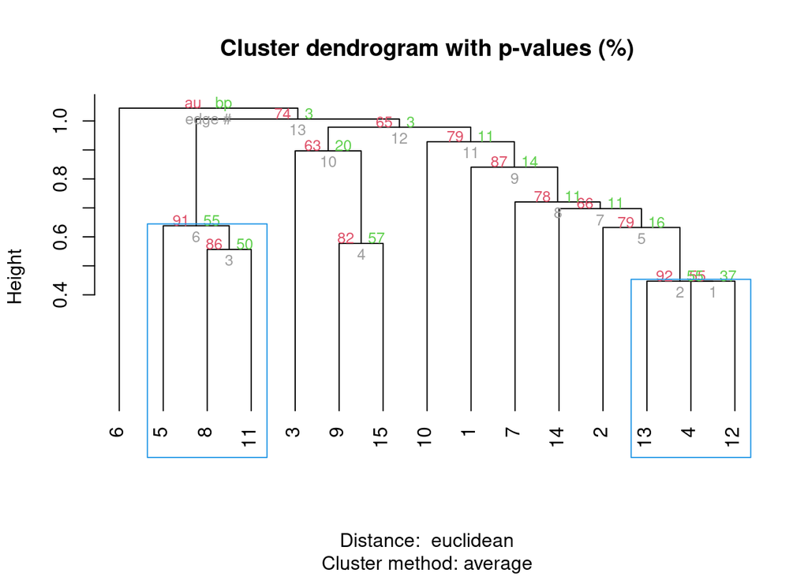

```r
# Añadir los valores de p
plot(cl_pvclust_upgma, hang = -1)
# Añadir rectángulos a los grupos significativos
lines(cl_pvclust_upgma)
pvrect(cl_pvclust_upgma, alpha = 0.90, border = 4)
```

Lo aplicaré también al árbol generado por el método Ward.

```r
# Ward
if(interactive()) dev.new()
cl_pvclust_ward <-
        pvclust(t(mc_t),
                method.hclust = "ward.D2",
                method.dist = "euc",
                iseed = 99, # Resultado reproducible
                parallel = TRUE)
```

```
## Creating a temporary cluster...done:
## socket cluster with 7 nodes on host 'localhost'
## Multiscale bootstrap... Done.
```

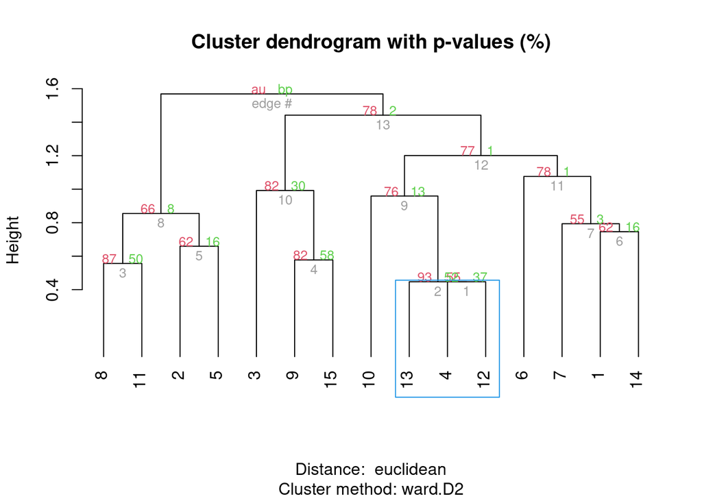

```r
# Añadir los valores de p
plot(cl_pvclust_ward, hang = -1)
# Añadir rectángulos a los grupos significativos
lines(cl_pvclust_ward)
pvrect(cl_pvclust_ward, alpha = 0.91, border = 4)
```

### 0.2.4 Conclusión sobre agrupamiento

```r
knitr::knit_exit()
```

Borcard, Daniel, François Gillet, and Pierre Legendre. 2018. *Numerical Ecology with r*. Springer.